# 02_Intro_CTA_NLP_Solutions

## Introduction to Natural Language Processing (NLP) using Python's NLTK

One of the most frequent tasks in computational text analysis is quickly summarizing the content of text. In this lesson we will learn two ways of summarizing text using Python's nltk, and in the process learn some quick and easy NLP techniques.

Natural Language Processing is an umbrella term that incorporates many techniques and methods to process, analyze, and understand natural languages (as opposed to artificial languages like logics, or Python).

### 0. Overview

#### Learning Goals:

The goal of this lesson is to jump right into text analysis and natural language processing. Rather than starting with the nitty gritty of programming in Python, this lesson will demonstrate some neat things you can do with a minimal amount of coding and will give you an understanding of why you may want to learn the nitty gritty. An additional goal of this lesson is to start to get you thinking about analyzing texts via computational methods.  
By the end of the lesson you will learn how to quickly summarize a text via counting the most frequent words, nouns, and verbs. More specifically, you will:

- Gain an intuition about how computers process text, and how this is different than how humans read it
- Learn some of the basic functions in the nltk package, such as tokenizing texts and part-of-speech tagging, and learn why these might help researchers analyze text
- Get started with some basic coding (although don't worry if you don't understand everything)

#### Lesson Outline:

1. Assigning Text as Variables in Python
   - Exercise 1.1
2. Tokenizing Text and Counting Words
   - Exercise 2.1
3. Pre-Processing:
   - Changing words to lowercase
   - Removing stop words
   - Removing punctuation
   - Exercise 3.1
4. Part-of-Speech Tagging
   - Exercise 4.1
5. Illustration: Guess the Unknown Text
   - Exercise 5.1
6. Word Frequency Plot
   - Exercise 6.1
7. Part-of-Speech Tagging
   - Tagging tokens
   - Counting tagged tokens
   - Exercise 7.1
8. If there's time: concordances

#### Key Jargon:

- *coding or programming*:
  - The purpose of programming is to find a sequence of instructions that will enable a computer to perform a specific task or solve a given problem. It involves writing those instructions in a specific *programming language*, in our case, Python.
- *script*:
  - A block of executable code, typically saved in a executable file. For example, script1.py
- *packages and modules*:
  - Python files, or collections of files, that implement a set of pre-made functions (so we don't have to write all of the functions ourselves). To utilize a module we use the import function.
- *parse*:
  - the process of analysing a string of symbols, in this case the symbols that make up natural language. This can also include understanding, or parsing, computer code.
- *variable*:
  - A variable is something that holds a value that may change. In simplest terms, a variable is just a box that you can put stuff in. You can use variables to store all kinds of stuff, including numbers and letters.
- *assigning a variable*:
  - telling Python what you want to name the variable, and what is stored in the variable.
- *string*:
  - a type of variable the consists of a sequence of characters in a particular order. Characters can be anything, including letters or numbers. The order of a string is fixed.
- *list*:
  - a type of variable that consists of a sequence of elements. The order is fixed.
- *stop words*:
  - the most common words in a language.

#### Further Resources:

Check out the full range of techniques included in Python's nltk package here: http://www.nltk.org/book/

### 1. Assigning Text as a Variable in Python

First, we assign a sample sentence, our "text", to a variable called "sentence" (the name of the variable is arbitrary). Printing the sentence shows what the variable "sentence" contains.

Note: This sentence is a quote about what digital humanities means, from digital humanist Kathleen Fitzpatrick. Source: "On Scholarly Communication and the Digital Humanities: An Interview with Kathleen Fitzpatrick", *In the Library with the Lead Pipe*

```python
#Anything on a line starting with a hashtag is called a comment, and is meant to clarify code for human readers.
#The computer ignores these lines.

#assign the desired sentence to the variable called 'sentence.' This variable type is called a string.
sentence = "For me it has to do with the work that gets done at the crossroads of digital media and traditional humanistic study. And that happens in two different ways. On the one hand, it’s bringing the tools and techniques of digital media to bear on traditional humanistic questions; on the other, it’s also bringing humanistic modes of inquiry to bear on digital media."

#print the contents of the variable 'sentence'
print(sentence)
```

```
For me it has to do with the work that gets done at the crossroads of digital media and traditional humanistic study. And that happens in two different ways. On the one hand, it’s bringing the tools and techniques of digital media to bear on traditional humanistic questions; on the other, it’s also …
```

```python
#First import the Python package nltk (Natural Language Tool Kit)
import nltk

#import the function to split the text into separate words from the NLTK package
from nltk import word_tokenize

#create new variable that applies the word_tokenize function to our sentence.
sentence_tokens = word_tokenize(sentence)

#This new variable contains the tokenized text, and is now a variable type called a list.
print(sentence_tokens)
```

```
['For', 'me', 'it', 'has', 'to', 'do', 'with', 'the', 'work', 'that', 'gets', 'done', 'at', 'the', 'crossroads', 'of', 'digital', 'media', 'and', 'traditional', 'humanistic', 'study', '.', 'And', 'that', 'happens', 'in', 'two', 'different', 'ways', '.', 'On', 'the', 'one', 'hand', ',', 'it’s', 'brin…
```

#### Exercise 1.1

Use the space below to complete the following tasks:

1. Create a new variable called `test_sentence` and assign the following content to `test_sentence`: "The itsy bitsy spider climbed up the waterspout. Down came the rain; and washed the spider out. Out came the sun; and dried up all the rain; and the itsy bitsy spider climbed up the spout again."
2. Print the variable `test_sentence`
3. Create a new variable called `test_sentence_tokens` that applies the `word_tokenize` function to `test_sentence`
4. Print the variable `test_sentence_tokens`

```python
# This is a comment.  It's a good idea to use comments to describe what you are doing with your code.
# Enter a comment for each of the steps in exercise 0.1, and then enter the solution below it.

# 1. creating test sentence variable
test_sentence = "The itsy bitsy spider climbed up the waterspout. Down came the rain; and washed the spider out. Out came the sun; and dried up all the rain; and the itsy bitsy spider climbed up the spout again."

# 2. Printing the sentence
print(test_sentence)

# 3. Create test_sentence_tokens
test_sentence_tokens = word_tokenize(test_sentence)

# 4. Print test_sentence_tokens
print(test_sentence_tokens)
```

```
The itsy bitsy spider climbed up the waterspout. Down came the rain; and washed the spider out. Out came the sun; and dried up all the rain; and the itsy bitsy spider climbed up the spout again.
['The', 'itsy', 'bitsy', 'spider', 'climbed', 'up', 'the', 'waterspout', '.', 'Down', 'came', 'the', 'rain', ';', 'and', 'washed', 'the', 'spider', 'out', '.', 'Out', 'came', 'the', 'sun', ';', 'and', 'dried', 'up', 'all', 'the', 'rain', ';', 'and', 'the', 'itsy', 'bitsy', 'spider', 'climbed', 'up',…
```

### 2. Tokenizing Text and Counting Words

The above output is how a human would read that sentence. Next we look at different ways in which a computer "reads", or *parses*, that sentence, and some simple ways to analyze/summarize it.

Often the first step needed to enable a computer to parse text is changing the sentence into "tokens." This is referred to as *tokenizing* text. Each token roughly corresponds to either words or punctuation. In essence, this process divides the sentence into little bits that the computer can process.

Notice each token is either a word or punctuation. [Note: in the coming days we will see other methods to tokenize text. While seemingly simple, tokenizing text is not a trivial task.]

Why is this helpful?

We can now summarize the sentence/text in interesting and potentially helpful ways. For example, we can count the number of tokens in the sentence, which roughly corresponds to the number of words.

```python
#The number of tokens is the length of the list, or the number of elements in the list
print(len(sentence_tokens))
```

```
69
```

We can also count the most frequent words, which can help us quickly summarize the text.

```python
#apply the nltk function FreqDist to count the number of times each token occurs.
word_frequency = nltk.FreqDist(sentence_tokens)

#print out the 10 most frequent words using the function most_common
print(word_frequency.most_common(10))
```

```
[('the', 5), ('humanistic', 3), ('to', 3), ('of', 3), ('on', 3), ('digital', 3), ('media', 3), ('.', 3), ('bear', 2), (',', 2)]
```

But there are many frequent words that are not helpful in summarizing the text, for example, "the", "and", "to", and "." So the most frequent words do not necessarily help us understand the content of a text.

How can we use a computer to identify important, interesting, or content words in a text? There are many ways to do this, a few of which we'll cover in this workshop. Today, we'll look at two simple ways to identify words that will help us summarize the content of a text. We'll see additional ways of doing this in future workshops.

#### Exercise 2.1

In the space provided below, write a comment describing each step of your process, then write code to answer the following questions and execute the following tasks:

1. How many tokens appear in the sentence we used in exercise 1.1 above?
2. Create a new variable that counts the number of times each token occurs.
3. Print the five most common words

```python
# How many tokens appear in the sentence we used in exercise 1.1 above?
print(len(test_sentence_tokens))

# Create a new variable that counts the number of times each token occurs.
test_word_frequency = nltk.FreqDist(test_sentence_tokens)

# Print the five most common words
print(test_word_frequency.most_common(5))
```

```
43
[('the', 7), (';', 3), ('up', 3), ('spider', 3), ('.', 3)]
```

### 3. Pre-Processing: Lower Case, Removing Stop Words and Punctuation

First, scholars typically go through a number of pre-processing steps before getting to the actual analysis. One of these step is converting all words to lower-case, so that the word "Humanities" and "humanities" count as the same word. (For some tasks this is appropriate. Think of reasons why we might NOT want to do this.)

To convert to lower case we use the function lower()

```python
sentence_tokens_lc = [word.lower() for word in sentence_tokens]

#see the result
print(sentence_tokens_lc)
```

```
['for', 'me', 'it', 'has', 'to', 'do', 'with', 'the', 'work', 'that', 'gets', 'done', 'at', 'the', 'crossroads', 'of', 'digital', 'media', 'and', 'traditional', 'humanistic', 'study', '.', 'and', 'that', 'happens', 'in', 'two', 'different', 'ways', '.', 'on', 'the', 'one', 'hand', ',', 'it’s', 'brin…
```

Words like "the", "to", and "and" are what text analysis call "stop words." Stop words are the most common words in a language, and while necessary and useful for some analysis purposes, do not tell us much about the *substance* of a text. Another common pre-processing steps is to simply remove punctuation and stop words. NLTK contains a built-in stop words list, which we use to remove stop words from our list of tokens.

```python
#import the stopwords list
from nltk.corpus import stopwords

#take a look at what stop words are included:
print(stopwords.words('english'))
```

```
['i', 'me', 'my', 'myself', 'we', 'our', 'ours', 'ourselves', 'you', 'your', 'yours', 'yourself', 'yourselves', 'he', 'him', 'his', 'himself', 'she', 'her', 'hers', 'herself', 'it', 'its', 'itself', 'they', 'them', 'their', 'theirs', 'themselves', 'what', 'which', 'who', 'whom', 'this', 'that', 'the…
```

```python
#create a new variable that contains the sentence tokens without the stopwords
sentence_tokens_clean = [word for word in sentence_tokens_lc if word not in stopwords.words('english')]

#see what words we're left with
print(sentence_tokens_clean)
```

```
['work', 'gets', 'done', 'crossroads', 'digital', 'media', 'traditional', 'humanistic', 'study', '.', 'happens', 'two', 'different', 'ways', '.', 'one', 'hand', ',', 'it’s', 'bringing', 'tools', 'techniques', 'digital', 'media', 'bear', 'traditional', 'humanistic', 'questions', ';', ',', 'it’s', 'al…
```

Punctuation also does not help us understand the substance of a text, so we'll remove punctuation in a similar fashion. [Again, think about tasks where me may not want to remove punctuation.] There are many many ways to do this. For now, we'll create a list of punctuation tokens, similar to the list of stop words, and remove them from our list of tokens.

```python
#create a list of punctuation symbols
#there are better ways to do this which we'll get to later, but we'll keep it simple here
punctuation = [".", ";", ",", "'","’", '"', "!"]
sentence_tokens_clean = [word for word in sentence_tokens_clean if word not in punctuation]

#see what's left
print(sentence_tokens_clean)
```

```
['work', 'gets', 'done', 'crossroads', 'digital', 'media', 'traditional', 'humanistic', 'study', 'happens', 'two', 'different', 'ways', 'one', 'hand', 'it’s', 'bringing', 'tools', 'techniques', 'digital', 'media', 'bear', 'traditional', 'humanistic', 'questions', 'it’s', 'also', 'bringing', 'humanis…
```

Now, after our pre-processing steps, let's re-count the most frequent words in the sentence.

```python
word_frequency_clean = nltk.FreqDist(sentence_tokens_clean)
print(word_frequency_clean.most_common(10))
```

```
[('media', 3), ('humanistic', 3), ('digital', 3), ('bringing', 2), ('bear', 2), ('it’s', 2), ('traditional', 2), ('done', 1), ('modes', 1), ('tools', 1)]
```

Better! The 10 most frequent words now give us a pretty good sense of the substance of this sentence. But we still have problems. For example, the word "it's" sneaked in there. One solution is to keep adding stop words to our stop word list, but this could go on forever and is not a good solution when processing lots of text. There's another way of identifying content words, and it involves identifying the part of speech of each word, which we'll cover in the next section.

Before we turn to that, let's look at another set of helpful operations which help us to understand how common words are.

#### Exercise 3.1

For this exercise we'll undertake a few manipulations to help you familiarize yourself with the code above.

1. Create a version of the sentence from exercise 1.1 that is free from stopwords.
2. Create a version of the sentence from exercise 1.1 that is free from punctuation.
3. Print the tokenized sentence from exercise 1.1 without stopwords or punctuation.
4. Print the most frequent words from the example in 1.1 after removing stopwords and punctuation.
5. EXTRA CREDIT: Can you create and print a variable with the sentence from this section into all *UPPERCASE*?

```python
#FIRST CONVERT TO LOWERCASE!!!
test_sentence_tokens_lc = [word.lower() for word in test_sentence_tokens]

# Create a version of the sentence from exercise 1.1 that is free from stopwords.
test_sentence_tokens_clean = [word for word in test_sentence_tokens_lc if word not in stopwords.words('english')]

# Create a version of the sentence from exercise 1.1 that is free from punctuation.
test_sentence_tokens_clean = [word for word in test_sentence_tokens_clean if word not in punctuation]

# Print the tokenized sentence from exercise 1.1 without stopwords or punctuation.
print(test_sentence_tokens_clean)

# Print the most frequent words from the example in 1.1 after removing stopwords and punctuation.
test_word_frequency_clean = nltk.FreqDist(test_sentence_tokens_clean)
print(test_word_frequency_clean.most_common(10))

# EXTRA CREDIT: Can you create and print a variable with the sentence from this section into all UPPERCASE?
test_sentence_tokens_uc = [word.upper() for word in test_sentence_tokens]
print(test_sentence_tokens_uc)
```

```
['itsy', 'bitsy', 'spider', 'climbed', 'waterspout', 'came', 'rain', 'washed', 'spider', 'came', 'sun', 'dried', 'rain', 'itsy', 'bitsy', 'spider', 'climbed', 'spout']
[('spider', 3), ('came', 2), ('itsy', 2), ('climbed', 2), ('bitsy', 2), ('rain', 2), ('washed', 1), ('waterspout', 1), ('spout', 1), ('dried', 1)]
['THE', 'ITSY', 'BITSY', 'SPIDER', 'CLIMBED', 'UP', 'THE', 'WATERSPOUT', '.', 'DOWN', 'CAME', 'THE', 'RAIN', ';', 'AND', 'WASHED', 'THE', 'SPIDER', 'OUT', '.', 'OUT', 'CAME', 'THE', 'SUN', ';', 'AND', 'DRIED', 'UP', 'ALL', 'THE', 'RAIN', ';', 'AND', 'THE', 'ITSY', 'BITSY', 'SPIDER', 'CLIMBED', 'UP',…
```

### 4. Part-of-Speech Tagging

You may have noticed that stop words are typically short function words. Intuitively, if we could identify the part of speech of a word, we would have another way of identifying words of substance. NLTK can do that too!

NLTK has a function that will tag the part of speech of every token in a text. For this, we go back to our original tokenized text, with the stop words and punctuation.

NLTK uses the Penn Treebank Project to tag the part-of-speech of the words. You can find a list of all the part-of-speech tags here:

https://www.ling.upenn.edu/courses/Fall_2003/ling001/penn_treebank_pos.html

```python
#use the nltk pos function to tag the tokens
tagged_sentence_tokens = nltk.pos_tag(sentence_tokens)

#view new variable
print(tagged_sentence_tokens)
```

```
[('For', 'IN'), ('me', 'PRP'), ('it', 'PRP'), ('has', 'VBZ'), ('to', 'TO'), ('do', 'VB'), ('with', 'IN'), ('the', 'DT'), ('work', 'NN'), ('that', 'WDT'), ('gets', 'VBZ'), ('done', 'VBN'), ('at', 'IN'), ('the', 'DT'), ('crossroads', 'NNS'), ('of', 'IN'), ('digital', 'JJ'), ('media', 'NNS'), ('and', '…
```

Now comes more complicated code. Stay with me, but focus more on the output and understanding ways in which you as a researcher can use the output, rather than understanding every line of code.

We can count the part-of-speech tags in a similar way we counted words, to output the most frequent types of words in our text.

```python
tagged_frequency = nltk.FreqDist(tag for (word, tag) in tagged_sentence_tokens)
tagged_frequency.most_common()
```

```
[('IN', 11),
 ('JJ', 10),
 ('NNS', 9),
 ('NN', 6),
 ('DT', 6),
 ('VBZ', 3),
 ('.', 3),
 ('CC', 3),
 ('VB', 3),
 ('TO', 3),
 ('PRP', 2),
 (',', 2),
 ('CD', 2),
 ('VBG', 2),
 (':', 1),
 ('VBN', 1),
 ('WDT', 1),
 ('RB', 1)]
```

This sentence contains a lot of adjectives. So let's first look at the most frequent adjectives:

```python
adjectives = [word for word,pos in tagged_sentence_tokens if pos == 'JJ' or pos=='JJR' or pos=='JJS']

#print all of the adjectives
print(adjectives)
```

```
['digital', 'traditional', 'humanistic', 'different', 'digital', 'traditional', 'humanistic', 'other', 'humanistic', 'digital']
```

```python
#calculate the frequency of the adjectives
freq_adjectives=nltk.FreqDist(adjectives)

#print the most frequent adjectives
print(freq_adjectives.most_common(5))
```

```
[('digital', 3), ('humanistic', 3), ('traditional', 2), ('different', 1), ('other', 1)]
```

Let's do the same for verbs.

```python
verbs = [word for word,pos in tagged_sentence_tokens if pos == 'VB' or pos=='VBD' or pos=='VBG' or pos=='VBN' or pos=='VBP' or pos=='VBZ']

#print all of the verbs
print(verbs)
```

```
['has', 'do', 'gets', 'done', 'happens', 'bringing', 'bear', 'bringing', 'bear']
```

```python
#calculate the frequency of the verbs
freq_verbs=nltk.FreqDist(verbs)

#print the most frequent verbs
print(freq_verbs.most_common(5))
```

```
[('bringing', 2), ('bear', 2), ('do', 1), ('done', 1), ('has', 1)]
```

If we bring all of this together we get a pretty good summary of the sentence:

```python
print(freq_adjectives.most_common(3))
print(freq_verbs.most_common(3))
```

```
[('digital', 3), ('humanistic', 3), ('traditional', 2)]
[('bringing', 2), ('bear', 2), ('do', 1)]
```

#### Exercise 4.1

In the section above we tagged all the adjectives and the verbs, and we then compared the most frequent uses of each. For this exercise we'll do the same for nouns. The *pos* codes for nouns are `NN` and `NNS`.

1. Create a variable called `nouns` which contains all the tokens which are tagged `NN` or `NNS`
2. Print the variable `nouns`
3. Calculate the frequency of the `nouns`
4. print the most frequent `nouns`

```python
# Create a variable called nouns which contains all the tokens which are tagged "NN" or "NNS"
nouns = [word for word,pos in tagged_sentence_tokens if pos == 'NN' or pos=='NNS']

# Print the variable nouns
print(nouns)

# Calculate the frequency of the nouns
freq_nouns = nltk.FreqDist(nouns)

# print the most frequent nouns
print(freq_nouns.most_common(3))
```

```
['work', 'crossroads', 'media', 'study', 'ways', 'hand', 'it’s', 'tools', 'techniques', 'media', 'questions', 'it’s', 'modes', 'inquiry', 'media']
[('media', 3), ('it’s', 2), ('modes', 1)]
```

### 5. Illustration: Guess the Unknown Text

To illustrate this process on a slightly larger scale, we will do the exactly what we did above, but will do so on four unknown texts. Your challenge: guess the text from the most frequent words, nouns, and verbs. We will do this in one chunk of code, so another challenge for you during breaks or the next few weeks is to see how much of the following code you can follow (or, in computer science terms, how much of the code you can parse). If the answer is none, not to worry! The more you interact with other people's code, the more you'll be able to decide what is worth learning and what is worth *borrowing*.

Note: this codes requires one thing we haven't covered: reading a .txt file from your hard drive.

```python
#import the package 'string' for a different way of removing punctuation. It's simply a more complete list of punctuation than we created above.
import string
punctuations = list(string.punctuation)

#see what punctuation is included
print(punctuations)
```

```
['!', '"', '#', '$', '%', '&', "'", '(', ')', '*', '+', ',', '-', '.', '/', ':', ';', '<', '=', '>', '?', '@', '[', '\\', ']', '^', '_', '`', '{', '|', '}', '~']
```

```python
#read the text files from your hard drive, assign first unknown text to variable 'text1', the second text to variable 'text2', etc.
text1 = open('../../A-Data/text1.txt', encoding='utf-8').read()
text2 = open('../../A-Data/text2.txt', encoding='utf-8').read()
text3 = open('../../A-Data/text3.txt', encoding='utf-8').read()
text4 = open('../../A-Data/text4.txt', encoding='utf-8').read()

###word frequencies

#tokenize texts
text1_tokens = word_tokenize(text1)
text2_tokens = word_tokenize(text2)
text3_tokens = word_tokenize(text3)
text4_tokens = word_tokenize(text4)

#pre-process for word frequency
#lowercase
text1_tokens_lc = [word.lower() for word in text1_tokens]
text2_tokens_lc = [word.lower() for word in text2_tokens]
text3_tokens_lc = [word.lower() for word in text3_tokens]
text4_tokens_lc = [word.lower() for word in text4_tokens]

#remove stopwords
text1_tokens_clean = [word for word in text1_tokens_lc if word not in stopwords.words('english')]
text2_tokens_clean = [word for word in text2_tokens_lc if word not in stopwords.words('english')]
text3_tokens_clean = [word for word in text3_tokens_lc if word not in stopwords.words('english')]
text4_tokens_clean = [word for word in text4_tokens_lc if word not in stopwords.words('english')]

#remove punctuation using the list of punctuation from the string package
text1_tokens_clean = [word for word in text1_tokens_clean if word not in punctuations]
text2_tokens_clean = [word for word in text2_tokens_clean if word not in punctuations]
text3_tokens_clean = [word for word in text3_tokens_clean if word not in punctuations]
text4_tokens_clean = [word for word in text4_tokens_clean if word not in punctuations]

#frequency distribution
text1_word_frequency = nltk.FreqDist(text1_tokens_clean)
text2_word_frequency = nltk.FreqDist(text2_tokens_clean)
text3_word_frequency = nltk.FreqDist(text3_tokens_clean)
text4_word_frequency = nltk.FreqDist(text4_tokens_clean)

###part-of-speech frequencies

#tag part-of-speech
text1_tagged = nltk.pos_tag(text1_tokens)
text2_tagged = nltk.pos_tag(text2_tokens)
text3_tagged = nltk.pos_tag(text3_tokens)
text4_tagged = nltk.pos_tag(text4_tokens)

#most frequent nouns and verbs
text1_nouns = [word for word,pos in text1_tagged if pos=='NN' or pos=='NNS']
text2_nouns = [word for word,pos in text2_tagged if pos=='NN' or pos=='NNS']
text3_nouns = [word for word,pos in text3_tagged if pos=='NN' or pos=='NNS']
text4_nouns = [word for word,pos in text4_tagged if pos=='NN' or pos=='NNS']
text1_freq_nouns=nltk.FreqDist(text1_nouns)
text2_freq_nouns=nltk.FreqDist(text2_nouns)
text3_freq_nouns=nltk.FreqDist(text3_nouns)
text4_freq_nouns=nltk.FreqDist(text4_nouns)

text1_verbs = [word for word,pos in text1_tagged if pos == 'VB' or pos=='VBD' or pos=='VBG' or pos=='VBN' or pos=='VBP' or pos=='VBZ']
text2_verbs = [word for word,pos in text2_tagged if pos == 'VB' or pos=='VBD' or pos=='VBG' or pos=='VBN' or pos=='VBP' or pos=='VBZ']
text3_verbs = [word for word,pos in text3_tagged if pos == 'VB' or pos=='VBD' or pos=='VBG' or pos=='VBN' or pos=='VBP' or pos=='VBZ']
text4_verbs = [word for word,pos in text4_tagged if pos == 'VB' or pos=='VBD' or pos=='VBG' or pos=='VBN' or pos=='VBP' or pos=='VBZ']

text1_freq_verbs=nltk.FreqDist(text1_verbs)
text2_freq_verbs=nltk.FreqDist(text2_verbs)
text3_freq_verbs=nltk.FreqDist(text3_verbs)
text4_freq_verbs=nltk.FreqDist(text4_verbs)
```

All the variables are assigned as desired. We can now print out the most frequent words, nouns, and verbs for each text. Again, don't worry if you don't understand all the code here. [Note: many of these print statements are so humans can better read the output.]

```python
print("Frequent words for Text1:")
print("_________________________")

for word in text1_word_frequency.most_common(20):
    print(word[0])
print()
print("Frequent nouns for Text1")
print("________________________")
for word in text1_freq_nouns.most_common(20):
    print(word[0])
print()
print("Frequent verbs for Text1")
print("________________________")
for word in text1_freq_verbs.most_common(20):
    print(word[0])

print()
print("------------------------")
print("~~~~~~~~~~~~~~~~~~~~~~~~")
print("------------------------")
print()

print("Frequent words for Text2")
print("________________________")
for word in text2_word_frequency.most_common(20):
    print(word[0])

print()
print("Frequent nouns for Text2")
print("________________________")
for word in text2_freq_nouns.most_common(20):
    print(word[0])

print()
print("Frequent verbs for Text2")
print("________________________")
for word in text2_freq_verbs.most_common(20):
    print(word[0])

print()
print("------------------------")
print("~~~~~~~~~~~~~~~~~~~~~~~~")
print("------------------------")
print()

print("Frequent words for Text3:")
print("_________________________")

for word in text3_word_frequency.most_common(20):
    print(word[0])
print()
print("Frequent nouns for Text3")
print("________________________")
for word in text3_freq_nouns.most_common(20):
    print(word[0])
print()
print("Frequent verbs for Text3")
print("________________________")
for word in text3_freq_verbs.most_common(20):
    print(word[0])

print()
print("------------------------")
print("~~~~~~~~~~~~~~~~~~~~~~~~")
print("------------------------")
print()

print("Frequent words for Text4:")
print("_________________________")

for word in text4_word_frequency.most_common(20):
    print(word[0])
print()
print("Frequent nouns for Text4")
print("________________________")
for word in text4_freq_nouns.most_common(20):
    print(word[0])
print()
print("Frequent verbs for Text4")
print("________________________")
for word in text4_freq_verbs.most_common(20):
    print(word[0])
```

```
Frequent words for Text1:
_________________________
's
''
``
whale
one
like
upon
ahab
man
ship
old
would
ye
sea
though
yet
time
captain
long
still

Frequent nouns for Text1
________________________
whale
man
ship
sea
time
boat
head
way
whales
men
hand
thing
side
ye
world
```

[output cut: 232 more lines]

```
are
were
has
been
being
having
do
did
make
made
said
take
found
keep
hold
```

#### Exercise 5.1

No code here, just a few questions to think about:

1. Can you guess the text?
2. What further things can we learn from these lists? In particular, what can we learn from comparing these four texts?
3. What next steps would you want to take if you were to further compare these novels?

We can do many more things with the Python package NLTK. Pending time, here are a few other tricks.

### 6. Word Frequency Plot

In the section above we have succeeded in using the skills we've learned to compare commonly used words across texts. That can surface some of the unique elements within texts. To take this one step further, we can also depict these differences with graphs.

In the code below we will create a representation of the most frequent words which appear in our first text *Moby Dick*.

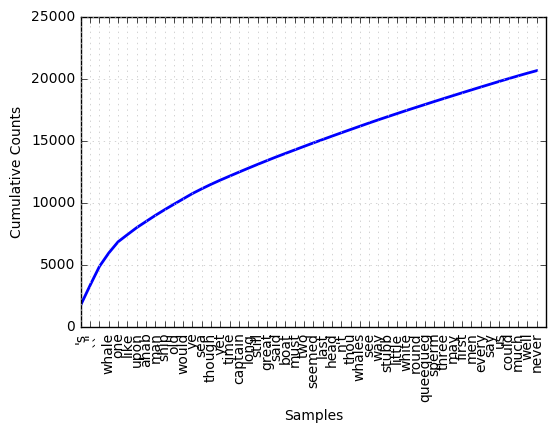

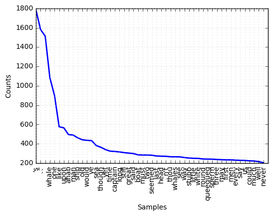

```python
text1_word_frequency.plot(50, cumulative=True)
text1_word_frequency.plot(50, cumulative=False)
```

#### Exercise 6.1

In the space below, write code that will produce similar graphs for the other three texts. Remember to comment you code as you compose it. Are the curves relatively similar?

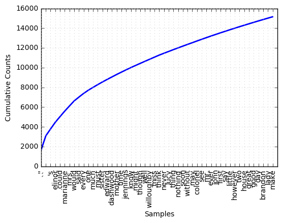

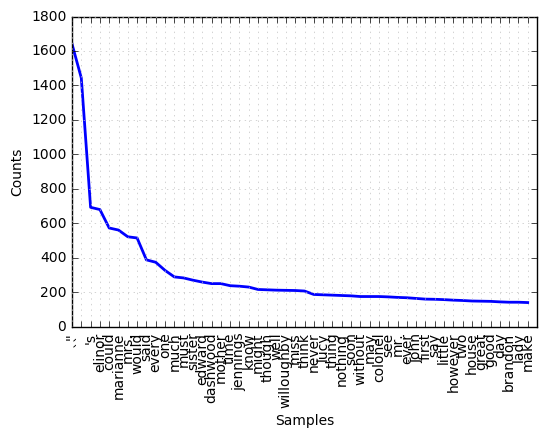

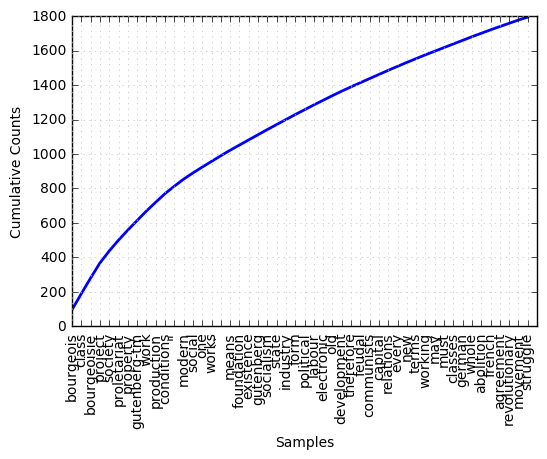

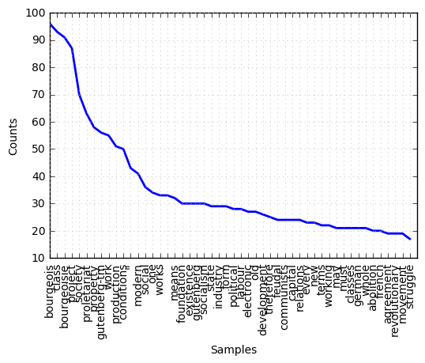

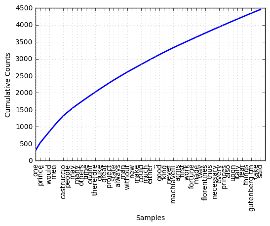

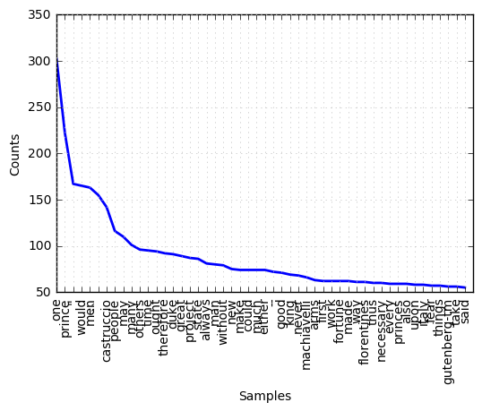

```python
# Solution for text2
text2_word_frequency.plot(50, cumulative=True)
text2_word_frequency.plot(50, cumulative=False)

# Solution for text3
text3_word_frequency.plot(50, cumulative=True)
text3_word_frequency.plot(50, cumulative=False)

# Solution for text4
text4_word_frequency.plot(50, cumulative=True)
text4_word_frequency.plot(50, cumulative=False)
```

### 7. Concordances and Similar Words using NLTK

Maybe we don't just want to know frequent words, but we want to know the way specific words are used. Concordances show us every occurrence of a given word, together with some context. This, combined with a function that should which words are used in a similar context as a given word, can help us understand the way in which a word is used in a text.

To illustrate this, we can compare the way the word "people" is used in our four texts. To use some nltk functions on text, for example concordances, we need to first transform the text into an NLTK text object. This will be useful for using these functions on your own text.

```python
#first tokenize the two texts
text1_tokens = word_tokenize(text1)
text2_tokens = word_tokenize(text2)
text3_tokens = word_tokenize(text3)
text4_tokens = word_tokenize(text4)

#then transform the tokenized text into an NLTK text object
text1_nltk = nltk.Text(text1_tokens)
text2_nltk = nltk.Text(text2_tokens)
text3_nltk = nltk.Text(text3_tokens)
text4_nltk = nltk.Text(text4_tokens)

#the variables text1_nltk and text2_nltk are now nltk text objects:
print(text1_nltk)
print(text2_nltk)
print(text3_nltk)
print(text4_nltk)
```

```
<Text: ETYMOLOGY . ( Supplied by a Late Consumptive...>
<Text: CHAPTER 1 The family of Dashwood had long...>
<Text: The Project Gutenberg EBook of The Communist Manifesto...>
<Text: The Project Gutenberg EBook of The Prince ,...>
```

```python
#now we can use the concordance function to display the word in its context
text1_nltk.concordance("people")
print()
text2_nltk.concordance("people")
print()
text3_nltk.concordance("people")
print()
text4_nltk.concordance("people")
print()
```

```
Displaying 25 of 46 matches:
 ! Paean ! Io ! sing . To the finny people 's king . Not a mightier whale than
 street , and methodically knocking people 's hats off—then , I account it hig
her . I do n't know how it is , but people like to be private when they are sl
 , and every one knows that in most people 's estimation , to do anything cool
ing authority ordered the scattered people to condense . `` Starboard gangway
ce comest thou ? Thy country ? What people ? But mark now , my shipmates , the
ut again he leaned over towards the people , and bowing his head lowly , with
so remained kneeling , till all the people had departed , and he was left alon
way he could get there—thrown among people as strange to him as though he were
ians , the arts whereby to make his people still happier than they were ; and
 wharf . As we were going along the people stared ; not at Queequeg so much—fo
hat , one would think . Did n't the people laugh ? '' Upon this , he told me a
is , he told me another story . The people of his island of Rokovoko , it seem
her . Grace being said , —for those people have their grace as well as we—thou
`` what you tink now ? —Did n't our people laugh ? '' At last , passage paid ,
ts of the true cross in Rome ; that people there plant toadstools before their
tifying saying about chowder-headed people ? `` But look , Queequeg , ai n't t
nk , or a nail or two in the ship . People in Nantucket invest their money in
rts , the king , chiefs , and great people generally , were in the custom of f
 engaged ; and several of the shore people were busy in bringing various last
 to establish the fact , that among people at large , the business of whaling
nd as in time of the cholera , some people go about with a camphorated handker
s is Charing Cross ; hear ye ! good people all , —the Greenland whale is depos
unched in pursuit of the game , the people of that island erected lofty spars
of those elusive thoughts that only people the soul by continually flitting th

Displaying 25 of 54 matches:
e attention to the comfort of other people she could act when occasion require
ertainly not ; but if you observe , people always live for ever when there is
in seeing the performances of other people , and I assure you he is by no mean
ted in him by the drawings of other people , was very far from that rapturous
 in collecting about him more young people than his house would hold , and the
ecting weddings among all the young people of her acquaintance . She was remar
ing and giving his opinion of other people , in sacrificing general politeness
'' `` But perhaps the abuse of such people as yourself and Marianne will make
 would be insufficient to make some people acquainted with each other , and se
the various endeavours of different people to quit the topic , it fell to the
ice to Marianne , `` There are some people who can not bear a party of pleasur
 here ? Are the Middletons pleasant people ? '' `` No , not all , '' answered
```

[output cut: 34 more lines]

```
and , Cesare Borgia , called by the people Duke Valentino , acquired his state
a and the Duchy of Urbino ; and the people now beginning to appreciate their p
o clear himself in the minds of the people , and gain them entirely to himself
barity of this spectacle caused the people to be at once satisfied and dismaye
e himself beloved and feared by the people , to be followed and revered by the
cily . One morning he assembled the people and the senate of Syracuse , as if
the senators and the richest of the people ; these dead , he seized and held t
in the palace , so that in fear the people were forced to obey him , and to fo
 a prince ought to live amongst his people in such a way that no unexpected ci
btained either by the favour of the people or by the favour of the nobles . Be
 , and from this it arises that the people do not wish to be ruled nor oppress
nobles wish to rule and oppress the people ; and from these two opposite desir
incipality is created either by the people or by the nobles , accordingly as o
, seeing they can not withstand the people , begin to cry up the reputation of
 give vent to their ambitions . The people , finding they can not resist the n
```

The nltk function *similar* prints out words that are used in the same context as *"people"*.

```python
print("Melville")
text1_nltk.similar("people")
print()
print("Austen")
text2_nltk.similar("people")
print()
print("Marx")
text3_nltk.similar("people")
print()
print("Machiavelli")
text4_nltk.similar("people")
print()
```

```
Melville
night captain whale ship time sea pequod man and day vessel rest
whales king sign lord harpooneers island waves chase

Austen
man you that months men him lady woman points and things relations
times her be himself who arguments certain signs

Marx
bourgeoisie donors right manufacturer power century german rest
proletariat prelude communists towns country first landlord

Machiavelli
prince state duke florentines soldiers enemy other church nobles
country romagna second king opportunity end orsini romans city castle
pope
```

What can we learn from this? We see a wide array of different context for this word which evokes different objectives frome each of the authors.

#### Exercise 7.1

In the space below, pick another word which you think might be interesting to compare across these texts. This is an interesting opportunity to start thinking about how best to utilize the methods we've gone over today.

1. Use the word you've chosen to print the concordances of that word.
2. Using nltk's "similar" function, print the words used in the context of your chosen word.

```python
# Use the word you've chosen to print the concordances of that word.
print("Melville")
text1_nltk.concordance("new")
print()
print("Austen")
text2_nltk.concordance("new")
print()
print("Marx")
text3_nltk.concordance("new")
print()
print("Machiavelli")
text4_nltk.concordance("new")
print()

# Using nltk's "similar" function, print the words used in the context of your chosen word.
print("Melville")
text1_nltk.similar("new")
print()
print("Austen")
text2_nltk.similar("new")
print()
print("Marx")
text3_nltk.similar("new")
print()
print("Machiavelli")
text4_nltk.similar("new")
print()
```

```
Melville
Displaying 25 of 84 matches:
ntucket , first mate of said vessel . New York , 1821 . `` A mariner sat in the
emen seem to have indirectly hit upon new clews to that same mystic North-West
ighed , I mean , in the scales of the New Testament ? Do you think the archange
y of old Manhatto , I duly arrived in New Bedford . It was a Saturday night in
enalties of whaling stop at this same New Bedford , thence to embark on their v
amazingly pleased me . Besides though New Bedford has of late been gradually mo
 another night following before me in New Bedford , ere I could embark for my d
ous young artist , in the time of the New England hags , had endeavored to deli
, where he bought up a lot of 'balmed New Zealand heads ( great curios , you kn
ight in one hand , and that identical New Zealand head in the other , the stran
middle of the room , he then took the New Zealand head—a ghastly thing enough—a
o the bag . He now took off his hat—a new beaver hat—when I came nigh singing o
always , though : Ledyard , the great New England traveller , and Mungo Park ,
aylight stroll through the streets of New Bedford . In thoroughfares nigh the d
s have often scared the natives . But New Bedford beats all Water Street and Wa
 haunts you see only sailors ; but in New Bedford , actual cannibals stand chat
s town scores of green Vermonters and New Hampshire men , all athirst for gain
how her visitors . Not at all . Still New Bedford is a queer place . Had it not
the dearest place to live in , in all New England . It is a land of oil , true
ks and gardens more opulent , than in New Bedford . Whence came they ? how plan
exander perform a feat like that ? In New Bedford , fathers , they say , give w
ew porpoises a-piece . You must go to New Bedford to see a brilliant wedding ;
 is art ; which in many a district of New Bedford has superinduced bright terra
ation 's final day . And the women of New Bedford , they bloom like their own r
CHAPTER 7 . The Chapel . In this same New Bedford there stands a Whaleman 's Ch

Austen
Displaying 25 of 31 matches:
er they leave Norland and settle in a new home . '' `` Well , then , LET someth
other for an entrance ; this , with a new drawing room which may be easily adde
ppetite of fifteen . The arrival of a new family in the country was always a ma
talking to her yesterday of getting a new grate for the spare bedchamber , she
delight of your conversation with our new friend . `` — Marianne was softened i
than he knows how to employ , and two new coats every year . '' `` Add to which
In Colonel Brandon alone , of all her new acquaintance , did Elinor find a pers
d give a general commission for every new print of merit to be sent you—and as
remained thoughtfully silent , till a new object suddenly engaged her attention
his , and Marianne 's blushing , gave new suspicions to Edward . `` And who is
```

[output cut: 69 more lines]

```

Melville
the him whale vermillion additional tashtego shock bold fiery
cautiousness beef every nantucket which yours ten pulse continuous
whales unconditional

Austen
numerous farther i and more

Marx
revolutionary real profane existing first old english

Machiavelli
wise good hereditary other of like warlike in benefited syracusan
ought unaspiring thee extinguished vulgar people enemy or prince ills
```